# STAT508_DAA6

Ada Lazuli

Thursday, Feb 26, 2026

## Front Matter

```r
remove(list = ls())
library(AmesHousing)
library(tidyverse)
library(ISLR2)
library(pls)
library(reactable)
library(glmnet)
```

## Code for Creating the Processed Dataset

```r
ames <- AmesHousing::make_ames()
dim(ames)
```

```
## [1] 2930   81
```

## Problem 1 - Prepare the Dataset for Analysis

#### Part a. - Subset to only include the numeric variables and remove observations with missing values

```r
ames2 <- ames %>% select(where(is.numeric))
ames2 <- na.omit(ames2)
dim(ames2)
```

```
## [1] 2930   35
```

#### Part b. - Perform a training/validation split

```r
set.seed(123)
trainInd <- sample(1:nrow(ames2), floor(0.8 * nrow(ames2)), replace = FALSE)
train <- ames2[trainInd,]
validation <- ames2[-trainInd,]
```

## Problem 2 - Perform Principal Component Regression (PCR)

#### Part a. - Fit a PCR model and display a summary of the results. Use 10-fold CV.

```r
set.seed(1)
pcrFit <- pcr(Sale_Price ~ ., data = train, center = TRUE, scale = TRUE, validation = "CV", segments = 10)
```

#### Part b. - Create a plot showing the cross validation RMSE values. How many components?

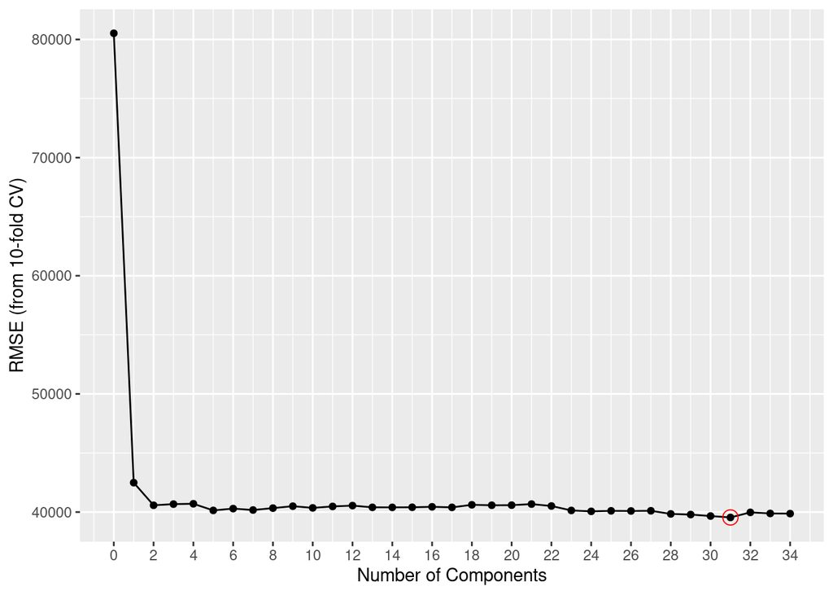

```r
tempRMSE <- RMSEP(pcrFit)
ggplotDF <- data.frame(Components = 0:(ncol(train)-1),
                       RMSE = tempRMSE$val[1, , ])
optMpcr <- which.min(tempRMSE$val[1, , ])

ggplot(data = ggplotDF, mapping = aes(x = Components, y = RMSE)) +
  geom_line() +
  geom_point() +
  geom_point(data = ggplotDF[optMpcr,], color = "red", shape = 1, size = 4) +
  scale_x_continuous(breaks = seq(0, ncol(train)-1, 2)) +
  labs(x = "Number of Components",
       y = "RMSE (from 10-fold CV)")
```

Based on the training cross fold valdation RSME, the optimal number of components is 31.

#### Part c. - Based on the optimal number of principal components chosen in the Part b., what percent of the variance in Sale_Price is explained by the PCR model using the training data?

```r
summary(pcrFit)
```

```
## Data:    X dimension: 2344 34
##  Y dimension: 2344 1
## Fit method: svdpc
## Number of components considered: 34
##
## VALIDATION: RMSEP
## Cross-validated using 10 random segments.
##        (Intercept)  1 comps  2 comps  3 comps  4 comps  5 comps  6 comps
## CV           80527    42488    40573    40671    40701    40138    40292
## adjCV        80527    42479    40559    40653    40681    40112    40180
##        7 comps  8 comps  9 comps  10 comps  11 comps  12 comps  13 comps
## CV       40172    40333    40496     40352     40475     40545     40399
## adjCV    40137    40285    40424     40264     40388     40428     40303
##        14 comps  15 comps  16 comps  17 comps  18 comps  19 comps  20 comps
## CV        40396     40404     40442     40397     40611     40575     40583
## adjCV     40306     40327     40359     40312     40477     40422     40449
##        21 comps  22 comps  23 comps  24 comps  25 comps  26 comps  27 comps
## CV        40673     40512     40135     40060     40102     40092     40106
## adjCV     40536     40375     40006     39900     39945     39927     39947
##        28 comps  29 comps  30 comps  31 comps  32 comps  33 comps  34 comps
## CV        39842     39787     39662     39543     39973     39881     39868
## adjCV     39654     39593     39461     39324     39733     39640     39594
##
## TRAINING: % variance explained
##             1 comps  2 comps  3 comps  4 comps  5 comps  6 comps  7 comps
## X             18.30    27.05    33.28    39.09    43.11    46.64    50.13
## Sale_Price    72.14    74.52    74.57    74.64    75.22    75.59    75.77
##             8 comps  9 comps  10 comps  11 comps  12 comps  13 comps  14 comps
## X             53.39    56.49     59.56     62.52     65.42     68.26     70.98
## Sale_Price    75.94    76.20     76.41     76.41     76.50     76.52     76.52
##             15 comps  16 comps  17 comps  18 comps  19 comps  20 comps
## X              73.59     76.16     78.62     81.02     83.24     85.43
## Sale_Price     76.52     76.54     76.63     76.96     77.16     77.24
##             21 comps  22 comps  23 comps  24 comps  25 comps  26 comps
## X              87.41     89.22     90.96     92.64     94.23     95.45
## Sale_Price     77.26     77.67     77.99     78.17     78.29     78.44
##             27 comps  28 comps  29 comps  30 comps  31 comps  32 comps
## X              96.52     97.50     98.37     98.94     99.38     99.73
## Sale_Price     78.44     79.17     79.40     79.67     80.15     80.16
##             33 comps  34 comps
## X             100.00     100.0
## Sale_Price     80.27      80.3
```

Based on the summary, 80.15% of the variation in `sale_price` is explained by the first 31 components.

#### Part d. - Compute the validation set mean squared error (MSE) and RMSE based on PCR with the optimal number of components.

```r
yhatPCR <- predict(pcrFit, newdata = validation, ncomp = 31)
MSEpcr <- mean((validation$Sale_Price - yhatPCR)^2)
RMSEpcr <- sqrt(MSEpcr)
RMSEpcr
```

```
## [1] 34920.8
```

The RMSE score against the validation set is **34920.8** with the PCR model

## Problem 3 - Perform Partial Least Squares Regression

#### Part a. - Fit a PLS regression model and display a summary of the results. Use 10-fold CV.

```r
set.seed(1)
plsFit <- plsr(Sale_Price ~ ., data = train,
               center = TRUE, scale = TRUE,
               validation = "CV", segments = 10)
```

#### Part b. - Create a plot showing the cross validation RMSE values. How many components?

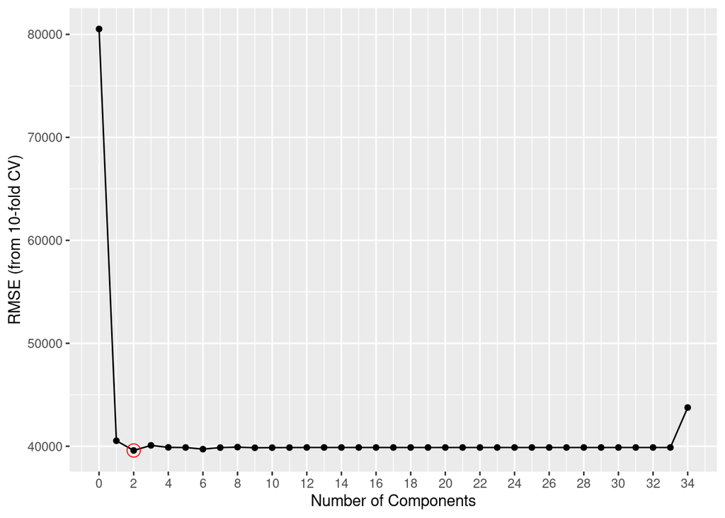

```r
tempRMSE <- RMSEP(plsFit)

ggplotDF <- data.frame(Components = 0:(ncol(train)-1),
                       RMSE = tempRMSE$val[1, , ])

optMpls <- which.min(tempRMSE$val[1, , ])
ggplot(data = ggplotDF, mapping = aes(x = Components, y = RMSE)) +
  geom_line() +
  geom_point() +
  geom_point(data = ggplotDF[optMpls,], color = "red", shape = 1, size = 4 ) +
  scale_x_continuous(breaks = seq(0, ncol(train)-1, 2)) +
  labs(x = "Number of Components",
       y = "RMSE (from 10-fold CV)")
```

Based on the RMSE score over 10 cross fold validations on the training set, it appears that using 2 components is optimal for PLS.

#### Part c. - Based on the optimal number of principal components chosen in the Part b., what percent of the variance in Sale_Price is explained by the PLS model using the training data?

```r
summary(plsFit)
```

[output not shown]

Two components in the PLS model explain 77.94% of the variance in `Sale_Price`

#### Part d. - Compute the validation set mean squared error (MSE) and RMSE based on PLS with the optimal number of components.

```r
yhatPLS <- predict(plsFit, newdata = validation, ncomp = 2)
MSEpls <- mean((validation$Sale_Price - yhatPLS)^2)
RMSEpls <- sqrt(MSEpls)
RMSEpls
```

```
## [1] 35576.64
```

The RMSE score against the validation set is **35576.64** with the PLS model

## Problem 4 - Comparing Methods

#### Part a. - Ordinary Least Square Linear Regression

```r
lrModel <- lm(Sale_Price ~ ., data = train)
yhatLR <- predict(lrModel, newdata = validation)
MSElr <- mean((validation$Sale_Price - yhatLR)^2)
RMSElr <- sqrt(MSElr)
RMSElr
```

```
## [1] 35157.14
```

#### Part b. - LASSO Regression

```r
# Create the matrices for LASSO and Ridge
Xmat <- model.matrix(Sale_Price ~ ., data = ames2)[, -1]
yvec <- ames2$Sale_Price

set.seed(123)
trainInd <- sample(1:nrow(ames2), floor(0.8*nrow(ames2)), replace = FALSE)
set.seed(NULL)
XmatTrain <- Xmat[trainInd,]
XmatVal <- Xmat[-trainInd,]
yvecTrain <- yvec[trainInd]
yvecVal <- yvec[-trainInd]

set.seed(1)
lassoCV <- cv.glmnet(x = XmatTrain, y = yvecTrain,
                    family = "gaussian",
                    alpha = 1,
                    lambda = NULL,
                    standardize = TRUE,
                    nfolds = 10)
lassoYhat <- predict(lassoCV, s = lassoCV$lambda.min, newx = XmatVal)
lassoMSE <-  mean((yvecVal - lassoYhat)^2)
lassoRMSE <- sqrt(lassoMSE)
lassoRMSE
```

```
## [1] 35270.88
```

#### Part c. - Ridge Regression

```r
set.seed(1)
ridgeCV <- cv.glmnet(x = XmatTrain, y = yvecTrain,
                    family = "gaussian",
                    alpha = 0,
                    lambda = NULL,
                    standardize = TRUE,
                    nfolds = 10)
ridgeYhat <- predict(ridgeCV, s = ridgeCV$lambda.min, newx = XmatVal)
ridgeMSE <-  mean((yvecVal - ridgeYhat)^2)
ridgeRMSE <- sqrt(ridgeMSE)
ridgeRMSE
```

```
## [1] 34883.64
```

#### Part d. - Which method worked the best?

```r
performance_df <- data.frame(Method = c("Linear Regression (All Features)", "PCR (31 Components)", "PLS (2 Components)", "LASSO", "Ridge"),
                             RMSEValidation = c(RMSElr, RMSEpcr, RMSEpls, lassoRMSE, ridgeRMSE))

performance_df <- performance_df %>% arrange(RMSEValidation) %>% mutate(RMSEValidation = round(RMSEValidation, digits = 2))

reactable(performance_df)
```

| Method | RMSEValidation |
| --- | --- |
| Ridge | 34883.64 |
| PCR (31 Components) | 34920.8 |
| Linear Regression (All Features) | 35157.14 |
| LASSO | 35270.88 |
| PLS (2 Components) | 35576.64 |

Based on the RMSE score against the validation set, it seems that Ridge regression performs the best against with held data it was not exposed to during training and it would follow that the Ridge model would perform the best against new observations in production.